# Differential Methylation Analysis on CpG (1KO_DKO)

# 14 Volcano plots with annotations

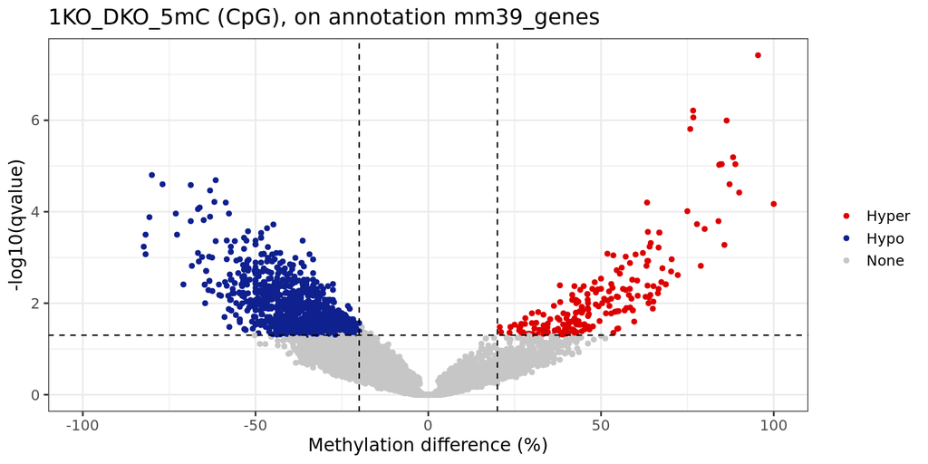

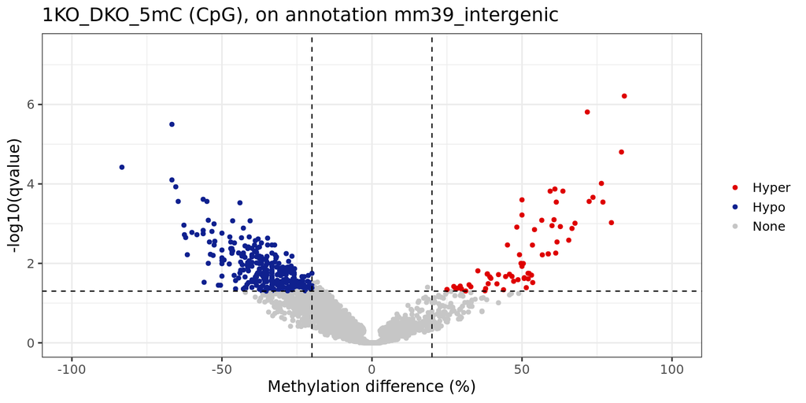

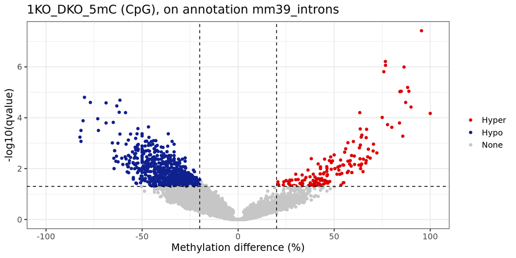

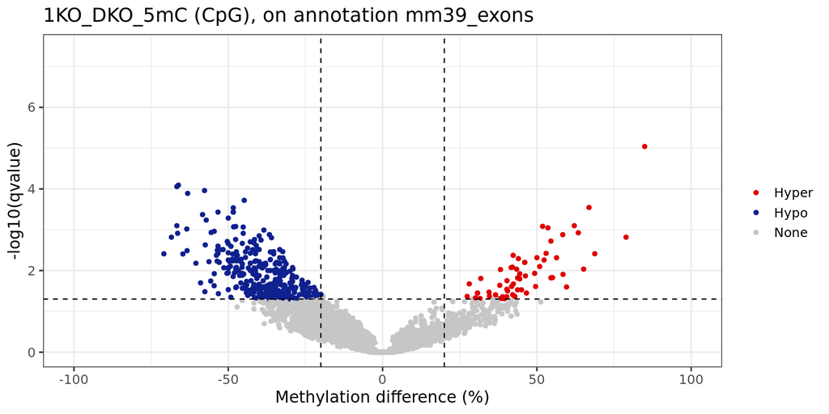

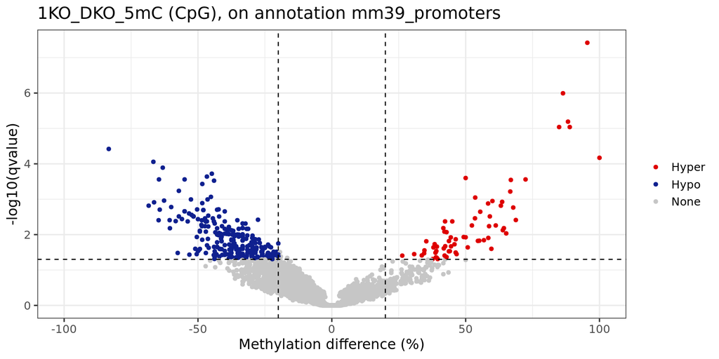

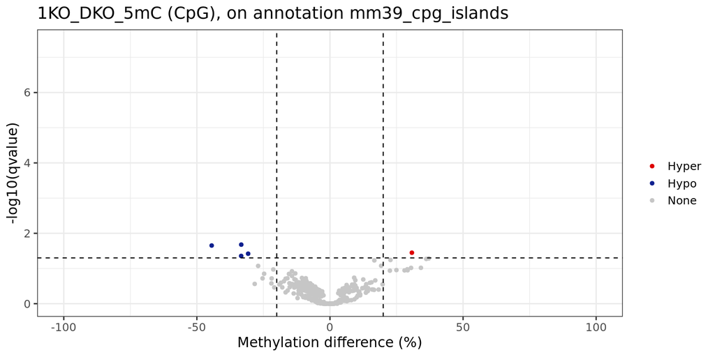

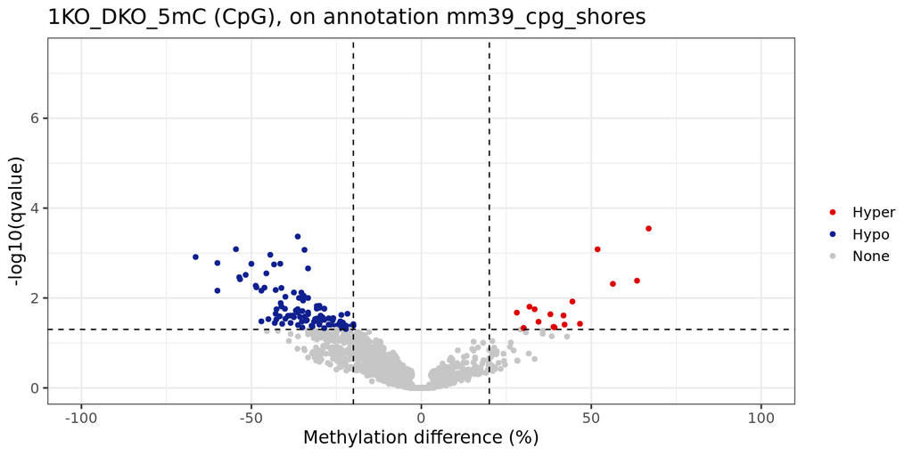

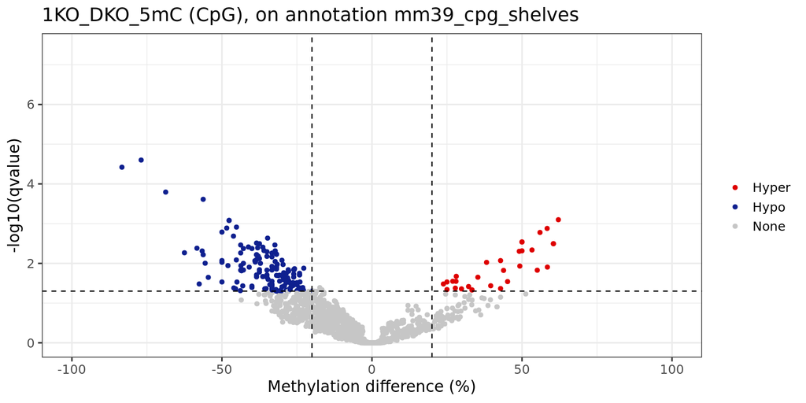

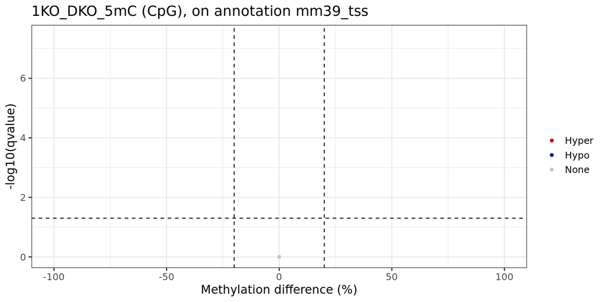

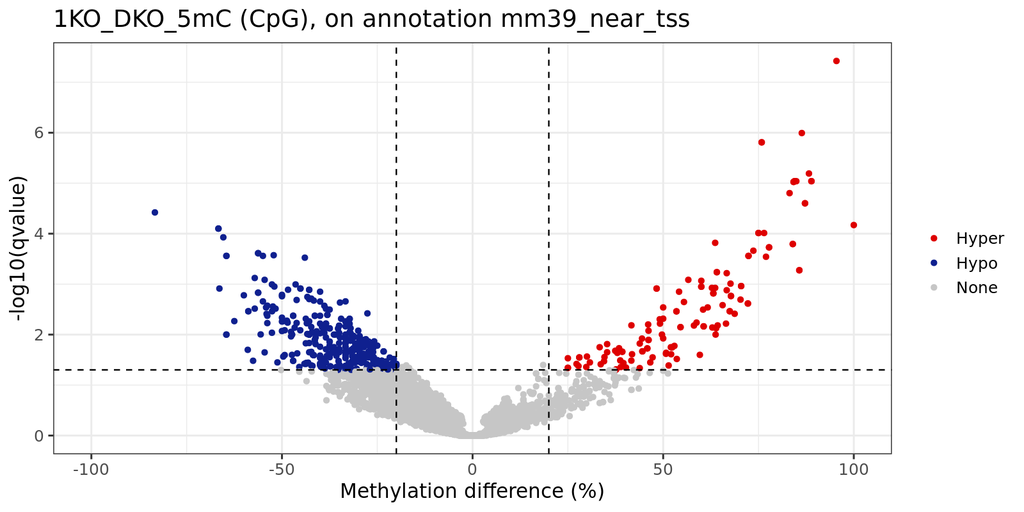

```r
for(i in IGV ){
  Adtdf <- AllDiffdm_annotated %>% data.frame
  Adtdf <- Adtdf[ which( Adtdf$annot.type %in% i ) , ]

  exist_annot <- row.names(table(Adtdf$annot.type))
  if(is.na(match(x = i , exist_annot)) == FALSE){

    Adtdf$annot.type <- factor(Adtdf$annot.type, levels = IGV[i] )

    vc_temp <- ggplot(data = Adtdf,
                      aes(x = meth.diff, y = -log10(qvalue), col = DM_status)) +
      geom_point() +
      theme_bw(base_size = 14) +
      labs(col = '') +
      xlab("Methylation difference (%)") +
      xlim(-100, 100) +
      ylim(0, -log10(ymax)) +
      scale_color_manual(values=c('Hyper' = hyper.color,
                                   'Hypo' = hypo.color,
                                   'None' = not.color)) +
      geom_vline(xintercept = c(-DIF, DIF), linetype="dashed", col="black") +
      geom_hline(yintercept = -log10(QV), linetype="dashed", col="black") +
      ggtitle(paste0(CONDI, " (", LEVEL, "), on annotation ", i))
    print(vc_temp)
  }
}
```

```r
rm(Adtdf)
rm(exist_annot)
```

# 15 Top differential methylation

```r
# MH corrected for cases with low number of differences
if (length(AllDiffdm_annotated) > 40){
    top_diff <- data.frame(AllDiffdm_annotated[AllDiffdm_annotated$pvalue <= sort(AllDiffdm_annotated$pvalue)[30] , ])
} else {
    top_diff <- data.frame(AllDiffdm_annotated[AllDiffdm_annotated$pvalue <= sort(AllDiffdm_annotated$pvalue), ])
}
top_diff <- top_diff[, c(1,2,3,6,20, 28, 30)]
colnames(top_diff) <- c("Chr", "start", "end", "Pval", "Status", "Gene ID", "Annotation")
knitr::kable(top_diff , "pipe")
```

| Chr | start | end | Pval | Status | Gene ID | Annotation |
| --- | --- | --- | --- | --- | --- | --- |
| chr19 | 3190364 | 3190364 | 0 | Hyper | ENSMUSG00000100969.8 | mm39_genes |
| chr19 | 3190364 | 3190364 | 0 | Hyper | NA | mm39_introns |
| chr19 | 3190364 | 3190364 | 0 | Hyper | ENSMUSG00000118966.1 | mm39_near_tss |
| chr19 | 3190364 | 3190364 | 0 | Hyper | ENSMUSG00000118182.2 | mm39_near_tss |
| chr19 | 3190406 | 3190406 | 0 | Hyper | ENSMUSG00000100969.8 | mm39_genes |
| chr19 | 3190406 | 3190406 | 0 | Hyper | NA | mm39_introns |
| chr19 | 3190406 | 3190406 | 0 | Hyper | ENSMUSG00000118966.1 | mm39_near_tss |
| chr19 | 3190406 | 3190406 | 0 | Hyper | ENSMUSG00000118182.2 | mm39_near_tss |
| chr19 | 3190828 | 3190828 | 0 | Hyper | ENSMUSG00000100969.8 | mm39_genes |
| chr19 | 3190828 | 3190828 | 0 | Hyper | NA | mm39_introns |
| chr19 | 3190828 | 3190828 | 0 | Hyper | ENSMUSG00000118966.1 | mm39_near_tss |
| chr19 | 3190828 | 3190828 | 0 | Hyper | ENSMUSG00000118182.2 | mm39_near_tss |
| chr19 | 3190828 | 3190828 | 0 | Hyper | ENSMUSG00000118182.2 | mm39_promoters |
| chr19 | 3192376 | 3192376 | 0 | Hyper | ENSMUSG00000100969.8 | mm39_genes |
| chr19 | 3192376 | 3192376 | 0 | Hyper | NA | mm39_introns |
| chr19 | 3192376 | 3192376 | 0 | Hyper | ENSMUSG00000118182.2 | mm39_near_tss |
| chr19 | 3192376 | 3192376 | 0 | Hyper | ENSMUSG00000118182.2 | mm39_promoters |
| chr19 | 3192378 | 3192378 | 0 | Hyper | ENSMUSG00000100969.8 | mm39_genes |
| chr19 | 3192378 | 3192378 | 0 | Hyper | NA | mm39_introns |
| chr19 | 3192378 | 3192378 | 0 | Hyper | ENSMUSG00000118182.2 | mm39_near_tss |
| chr19 | 3192378 | 3192378 | 0 | Hyper | ENSMUSG00000118182.2 | mm39_promoters |
| chr19 | 3192413 | 3192413 | 0 | Hyper | ENSMUSG00000100969.8 | mm39_genes |
| chr19 | 3192413 | 3192413 | 0 | Hyper | NA | mm39_introns |
| chr19 | 3192413 | 3192413 | 0 | Hyper | ENSMUSG00000118182.2 | mm39_near_tss |
| chr19 | 3192413 | 3192413 | 0 | Hyper | ENSMUSG00000118182.2 | mm39_promoters |
| chr19 | 3192943 | 3192943 | 0 | Hyper | ENSMUSG00000100969.8 | mm39_genes |
| chr19 | 3192943 | 3192943 | 0 | Hyper | NA | mm39_introns |
| chr19 | 3192943 | 3192943 | 0 | Hyper | ENSMUSG00000118182.2 | mm39_near_tss |
| chr19 | 3192943 | 3192943 | 0 | Hyper | ENSMUSG00000118182.2 | mm39_promoters |
| chr19 | 3192943 | 3192943 | 0 | Hyper | ENSMUSG00000118182.2 | mm39_exons |
| chr19 | 3192943 | 3192943 | 0 | Hyper | ENSMUSG00000118182.2 | mm39_genes |
| chr19 | 3808599 | 3808599 | 0 | Hypo | NA | mm39_intergenic |
| chr19 | 4077308 | 4077308 | 0 | Hyper | NA | mm39_intergenic |
| chr19 | 4596039 | 4596039 | 0 | Hyper | ENSMUSG00000024892.18 | mm39_genes |
| chr19 | 4596039 | 4596039 | 0 | Hyper | NA | mm39_introns |
| chr19 | 4913792 | 4913792 | 0 | Hyper | ENSMUSG00000006457.5 | mm39_genes |
| chr19 | 4913792 | 4913792 | 0 | Hyper | NA | mm39_introns |
| chr19 | 5006821 | 5006821 | 0 | Hyper | NA | mm39_intergenic |

```r
rm(top_diff)
```

# 16 Save list of genes associate to Tiles

```r
if(LEVEL == "Tiles"){

  df_alldiff <- data.frame(AllDiffdm_annotated)
  sort_alldif_annot <- df_alldiff[order(df_alldiff$pvalue, decreasing=FALSE),]
  sort_annotated_genes <- sort_alldif_annot[ sort_alldif_annot$annot.type == paste0(ORG, "_genes"),]
  background <- sort_annotated_genes[!duplicated(sort_annotated_genes[, "start"]),]
  write.csv(background, file= paste0(OUTPUT_PATH , CONDI,  "_background_tiles.csv"))

  sort_sig_annotated_genes <- sort_annotated_genes[sort_annotated_genes$Diff_expr == "Significant", ]
  write.csv(sort_sig_annotated_genes, file= paste0(OUTPUT_PATH , CONDI,  "_significant_annot_tiles.csv"))
  print(table(sort_sig_annotated_genes$DM_status))
}
```

# 17 Differential methylation by genomic annotations

Show the differential methylation status :  
- Hyper  
- Hypo  
- None  
On basic genomic annotation tracks.

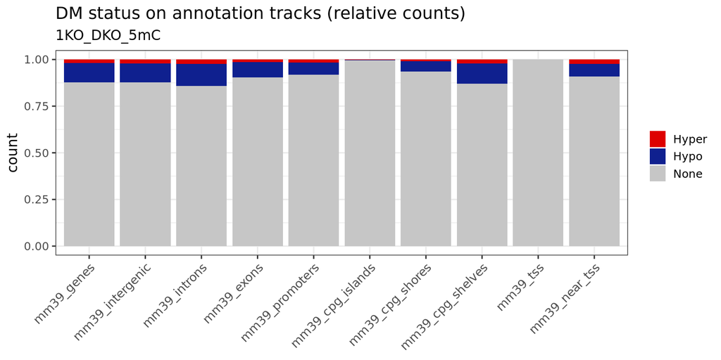

```r
#################################################################
#plot categorical

dm_annotated <- AllDiffdm_annotated  %>% data.frame
dm_annotated$annot.type <- factor(dm_annotated$annot.type , levels = IGV )


anno_re <- ggplot(data=dm_annotated, aes(x=annot.type, fill=DM_status)) +
  geom_bar(position = "fill") +
  scale_fill_manual("",
                    values = c( 'Hyper' = hyper.color,
                                'Hypo'  = hypo.color,
                                'None'  = not.color)
  ) +
  scale_x_discrete("", labels = gsub("ORG_", "", IGV ) ) +
  theme_bw(base_size = 14) +
  ggtitle( paste0('DM status on annotation tracks (relative counts)'),
           subtitle = paste0(CONDI) ) +
  theme(axis.text.x = element_text( size = 12, angle = 45, vjust = 1, hjust = 1),
        axis.title.x = element_blank(), legend.title = element_blank()
  )

anno_re
```

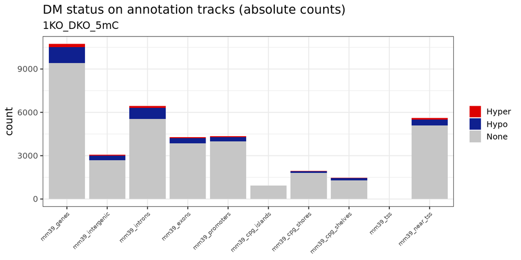

```r
anno_abs <- ggplot(data=dm_annotated, aes(x=annot.type, fill=DM_status)) +
  geom_bar() +
  scale_fill_manual("",
                    values = c( 'Hyper' = hyper.color,
                                'Hypo'  = hypo.color,
                                'None'  = not.color)
  ) +
  scale_x_discrete("", labels = gsub("ORG_", "", IGV) ) +
  theme_bw(base_size = 14) +
  ggtitle( paste0('DM status on annotation tracks (absolute counts)'),
           subtitle = paste0(CONDI) ) +
  theme(axis.text.x = element_text( size = 8, angle = 45, vjust = 1, hjust = 1),
        axis.title.x = element_blank(), legend.title = element_blank()
  )

anno_abs
```

# 18 Custom annotations

```r
if((CUSTOM_ANNOT == TRUE) && (merge_annot == FALSE)){

  library(GenomicRanges)
  library(annotatr)

  df_custom_tracks <- data.frame(list_custom_tracks[[1]])

  for(i in 2:length(list_custom_tracks)){

    df <- data.frame(list_custom_tracks[[i]])
    df_custom_tracks <- rbind(df_custom_tracks, df)
  }

  GR_custom_tracks <- makeGRangesFromDataFrame(df_custom_tracks, keep.extra.columns = TRUE)


  for(i in 1:length(unique(meta_annot$group))){

    print(i)

    AllDiffdm_annotated <- annotate_regions(regions = AllDiffdm_regions,
                                            annotations = GR_custom_tracks[GR_custom_tracks$group == unique(meta_annot$group)[i] ],
                                            ignore.strand = TRUE,
                                            quiet = TRUE)

    dm_annotated <- AllDiffdm_annotated  %>% data.frame
    dm_annotated$annot.type <- factor(dm_annotated$annot.type )

    anno_re_custom <- ggplot(data=dm_annotated, aes(x=annot.type, fill=DM_status)) +
    geom_bar(position = "fill") +
    scale_fill_manual("",
                      values = c( 'Hyper' = hyper.color,
                                  'Hypo'  = hypo.color,
                                  'None'  = not.color)
    ) +
    scale_x_discrete("", labels = gsub("ORG_", "", dm_annotated$annot.type ) ) +
    theme_bw(base_size = 14) +
    ggtitle( paste0('DM status on annotation tracks (relative counts)'),
             subtitle = paste0(CONDI) ) +
    theme(axis.text.x = element_text( size = 8, angle = 45, vjust = 1, hjust = 1),
          axis.title.x = element_blank(), legend.title = element_blank()
    )

    print(anno_re_custom)


    anno_abs_custom <- ggplot(data=dm_annotated, aes(x=annot.type, fill=DM_status)) +
      geom_bar() +
      scale_fill_manual("",
                        values = c( 'Hyper' = hyper.color,
                                    'Hypo'  = hypo.color,
                                    'None'  = not.color)
      ) +
      scale_x_discrete("", labels = gsub("ORG_", "", dm_annotated$annot.type) ) +
      theme_bw(base_size = 14) +
      ggtitle( paste0('DM status on annotation tracks (absolute counts)'),
               subtitle = paste0(CONDI) ) +
      theme(axis.text.x = element_text( size = 8, angle = 45, vjust = 1, hjust = 1),
            axis.title.x = element_blank(), legend.title = element_blank()
      )

    print(anno_abs_custom)

  }
  rm(df_custom_tracks)
  rm(GR_custom_tracks)
  rm(dm_annotated)
  rm(AllDiffdm_annotated)
}
```

## 18.1 Plot number of differentially methylated CpGs (or Tiles) by chromosome

For each chromosome show the number of DMCs/DMTs hypo or hyper-methylated  
The category named “others” correspond to chromsomes with unconventional names (like Unmapped chromsomes for example)

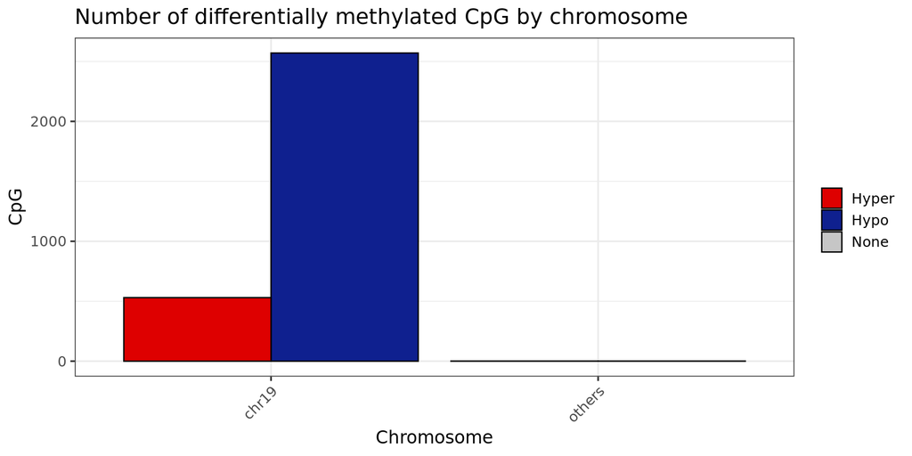

```r
if( dim(dfpc_Sig)[1] > 0){

  count_per_chromosome <- table(dfpc_Sig$chr, dfpc_Sig$DM_status)
  count_df <- as.data.frame.matrix(count_per_chromosome)
  count_df$chr <- rownames(count_df)


  # test si absence de hypo ou hyper
  if(dim(count_df)[2] == 2){
    if(colnames(count_df[1]) == "hypo"){
      count_df$Hyper <- rep(0, dim(count_df)[1])
    }else{
      count_df$Hypo <- rep(0, dim(count_df)[1])
    }
  }

  chr_others <- count_df[1,]
  rownames(chr_others) <- "others"
  chr_others$Hypo <- chr_others$Hyper <- 1
  chr_others$chr <- "others"

  delete_row <- 0

  for(i in 1:length(count_df$chr)){
    if((nchar(count_df$chr[i]) > 5) == TRUE){
      chr_others$Hypo <- (chr_others$Hypo + count_df[i,]$Hypo)
      chr_others$Hyper <- (chr_others$Hyper + count_df[i,]$Hyper)
      delete_row <- c(delete_row, i)
    }
  }

  if(is.na(delete_row[2]) == FALSE){ # test si il n'y a aucune colonne à remove (delete_row  = 0), car sinon génère des bugs
    count_df <- count_df[-delete_row,]
  }

  count_df<- rbind(count_df, chr_others)
  count_df$chr <- str_sort(count_df$chr, numeric = TRUE)
  count_df_long <- tidyr::gather(count_df, key = "status", value = "count", Hypo, Hyper)

  hist_dmr_chr <- ggplot(count_df_long, aes(x = chr, y = count, fill = status)) +
                            geom_bar(position = "dodge" , stat = "identity",  colour = "black") +
                            labs(title = paste0("Number of differentially methylated ", LEVEL, " by chromosome"),
                                 x = "Chromosome",
                                 y = LEVEL) +
                            theme_bw(base_size = 14) +
                            scale_fill_manual("", values=c('Hyper' = hyper.color,
                                                           'Hypo' = hypo.color,
                                                           'None' = not.color)) +
                            theme(axis.text.x = element_text(angle = 45, vjust = 1, hjust=1))


  rm(delete_row)
  rm(count_df, count_df_long)
  rm(chr_others)

  hist_dmr_chr
}
```

# 19 Save RDATA

Saves the whole R session of the script (variables, objects …)  
at the end of its execution. The RData file produced can then be opened in a local environment (if you have enough space)  
to make modifications. For example to retouch figures.

```r
save.image(file = PLOT_RDATA)
```

# 21 Links

- [UMR7216 Epigenetics And Cell Fate](http://parisepigenetics.com/)
- [BiBs : Bioinformatics and Biostatistics facifity](https://epigenetics.u-paris.fr/fr/bibs-bioinformatique-et-biostatistiques/)
- [WGBSFLOW Github](https://github.com/parisepigenetics/WGBSflow)
- [Methylator Github](https://github.com/parisepigenetics/Methylator)
[^1]: olivier.kirsh@u-paris.fr
[^2]: elouan.bethuel@etu.u-paris.fr